# DeepBlueR - DeepBlue Epigenomic Data Server - R package

## Filter for genomic regions of interest using annotations

In the next operation, we consider that not all methylation sites will be informative for clustering the data. We thus filter for those regions that are part of the BLUEPRINT regulatory build, a modified version of the [ENSEMBL regulatory build](http://www.ensembl.org/info/genome/funcgen/regulatory_build.html) that contains promoters, promoter flanking regions, enhancers, CTCF binding sites, transcription factor binding sites and open chromatin regions. As we can see, DeepBlueR returns a query id, which we store for later use.

```r
blueprint_regulatory_regions <- deepblue_select_annotations(
    annotation_name = "Blueprint Ensembl Regulatory Build",
    genome = "GRCh38")

blueprint_regulatory_regions
```

```
## [1] "q917484"
```

DeepBlue has several annotations that can be used to filter for informative sites. We could, for example, also filter for CpG islands.

```r
deepblue_select_annotations(annotation_name = "Cpg Islands",
                            genome = "GRCh38")
```

A list of all annotations currently available for a genome is given by the following command.

```r
deepblue_list_annotations(genome = "GRCh38")
```

```
##       id                                                 name
##  1:  a49                          Chromosomes size for GRCh38
##  2: a132                                            promoters
##  3: a161    Pattern TATAAA (non-overlap) in the genome GRCh38
##  4: a164                                          Cpg Islands
##  5: a239      Pattern TATA (non-overlap) in the genome GRCh38
##  6: a240        Pattern GC (non-overlap) in the genome GRCh38
##  7: a241        Pattern CG (non-overlap) in the genome GRCh38
##  8: a242 Pattern (TATA|CG) (non-overlap) in the genome GRCh38
##  9: a243         Pattern G (non-overlap) in the genome GRCh38
## 10: a244         Pattern C (non-overlap) in the genome GRCh38
## 11: a245       Pattern C|G (non-overlap) in the genome GRCh38
## 12: a246         Pattern A (non-overlap) in the genome GRCh38
## 13: a249                   Blueprint Ensembl Regulatory Build
```

New annotations may be included upon users request.

In case we want to include the entire genome in an aggregated version DeepBlue supports the concept of tiling regions. In this process, the genomic range of interest will be binned into tiles of a given size (here 5kb).

```r
tiling_regions <- deepblue_tiling_regions(size=5000,
                                          genome="GRCh38")
```

## Generate a score matrix

In the above step we have defined a set of regions of interest that we want to interrogate in R to, for example, cluster samples. To this end, DeepBlue can build a score matrix, in which the selected genomic regions are aggregated on the server to reduce the complexity and size of the data. We request such a score matrix in which regulatory regions are aggregated by the mean as follows. Note that we use the variables ‘exp_columns’ and ‘blueprint_regulatory_regions’ that we have defined above.

```r
request_id <- deepblue_score_matrix(
    experiments_columns = exp_columns,
    aggregation_function = "mean",
    aggregation_regions_id = blueprint_regulatory_regions)

request_id
```

```
## [1] "r789199"
```

After triggering this function, DeepBlue queues our task and will execute it when resources become available. We also observe that DeepBlue returns a request id, which we can use to query the status of the operation.

```r
deepblue_info(request_id)$state
```

```
## [1] "done"
```

```r
score_matrix <- deepblue_download_request_data(request_id = request_id)
```

[output not shown]

```r
score_matrix[,1:5, with=FALSE]
```

```
##         CHROMOSOME     START       END
##      1:       chr1     16047     30847
##      2:       chr1     19599     20609
##      3:       chr1     20892     21536
##      4:       chr1     24567     24911
##      5:       chr1     25804     26294
##     ---
## 528244:       chrX 156024218 156024915
## 528245:       chrX 156024974 156025400
## 528246:       chrX 156026242 156028242
## 528247:       chrX 156026442 156028042
## 528248:       chrY      6144      6409
##         C000S5A1bs.CPG_methylation_calls.bs_call.GRCh38.20160531.wig
##      1:                                                     0.581450
##      2:                                                     0.946625
```

[output cut: 21 more lines]

## Generating a heatmap

### Metadata and colors

In preparation of the heatmap plot, we need to generate an RColorBrewer palette. This allows us to create a color palette for more than 9 colors.

```r
getPalette <- colorRampPalette(brewer.pal(9, "Set1"))
```

For each experiment, we collect metadata.

```r
experiments_info <- deepblue_info(deepblue_extract_ids(blueprint_DNA_meth))
```

All metadata is parsed to a nested R list. We refer to the DeepBlue paper for a description of available metadata. Here, we show the metadata associated with just one of the samples.

```r
head(experiments_info[[1]], 10)
```

```
## $type
## [1] "experiment"
##
## $`_id`
## [1] "e93367"
##
## $data_type
## [1] "signal"
##
## $description
## [1] ""
##
## $epigenetic_mark
## [1] "dna methylation"
##
## $format
## [1] "CHROMOSOME,START,END,VALUE"
##
## $genome
## [1] "GRCh38"
##
## $name
## [1] "S00B2JA1.CPG_methylation_calls.bs_call.GRCh38.20160531.wig"
##
## $project
## [1] "BLUEPRINT Epigenome"
##
## $sample_id
## [1] "s10726"
```

For this analysis, we are only interested in the biosource name, i.e. the cell type. We can retrieve this information using standard R syntax. Note that we show only the first 6 entries here.

```r
biosource <- unlist(lapply(experiments_info, function(x){ x$sample_info$biosource_name}))
head(biosource)
```

```
## [1] "venous blood"
## [2] "central memory CD8-positive, alpha-beta T cell"
## [3] "CD8-positive, alpha-beta T cell"
## [4] "CD14-positive, CD16-negative classical monocyte"
## [5] "CD4-positive, alpha-beta T cell"
## [6] "germinal center B cell"
```

To save some space on the plot, we replace positive with + and negative with -.

```r
biosource <- str_replace_all(biosource, "-positive", "+")
biosource <- str_replace_all(biosource, "-negative", "-")
```

For the same reason, we remove the words ‘terminally differentiated’ from one of the cell types.

```r
biosource <- str_replace(biosource, ", terminally differentiated", "")
```

Using above color palette, we can now assign a unique color to each cell type.

```r
color_map <- data.frame(biosource = unique(biosource),
                        color = getPalette(length(unique(biosource))))

head(color_map)
```

```
##                                biosource   color
## 1                           venous blood #E41A1C
## 2 central memory CD8+, alpha-beta T cell #C52B37
## 3                CD8+, alpha-beta T cell #A63D53
## 4        CD14+, CD16- classical monocyte #874F6F
## 5                CD4+, alpha-beta T cell #68618A
## 6                 germinal center B cell #4A72A6
```

Using above table, we can now assign the colors to each experiment according to its cell type / biosource.

```r
exp_names <- unlist(lapply(experiments_info, function(x){ x$name}))

biosource_colors <- data.frame(name = exp_names, biosource = biosource)
biosource_colors <- dplyr::left_join(biosource_colors, color_map, by = "biosource")
head(biosource_colors)
```

```
##                                                           name
## 1   S00B2JA1.CPG_methylation_calls.bs_call.GRCh38.20160531.wig
## 2   C003VO56.CPG_methylation_calls.bs_call.GRCh38.20160531.wig
## 3   C003VO55.CPG_methylation_calls.bs_call.GRCh38.20160531.wig
## 4 C0010KA2bs.CPG_methylation_calls.bs_call.GRCh38.20160531.wig
## 5       P581.CPG_methylation_calls.bs_call.GRCh38.20160531.wig
## 6       G201.CPG_methylation_calls.bs_call.GRCh38.20160531.wig
##                                biosource   color
## 1                           venous blood #E41A1C
## 2 central memory CD8+, alpha-beta T cell #C52B37
## 3                CD8+, alpha-beta T cell #A63D53
## 4        CD14+, CD16- classical monocyte #874F6F
## 5                CD4+, alpha-beta T cell #68618A
## 6                 germinal center B cell #4A72A6
```

Finally, we transform this data frame into a vector that is compatible with the heatmap function.

```r
color_vector <- as.character(biosource_colors$color)
names(color_vector) <-  biosource_colors$biosource
head(color_vector)
```

```
##                           venous blood
##                              "#E41A1C"
## central memory CD8+, alpha-beta T cell
##                              "#C52B37"
##                CD8+, alpha-beta T cell
##                              "#A63D53"
##        CD14+, CD16- classical monocyte
##                              "#874F6F"
##                CD4+, alpha-beta T cell
##                              "#68618A"
##                 germinal center B cell
##                              "#4A72A6"
```

### Processing the input data

We remove the first three columns (CHROMOSOME, START, END) and convert the data frame to a numeric matrix.

```r
filtered_score_matrix <- as.matrix(score_matrix[,-c(1:3), with=FALSE])
head(filtered_score_matrix[,1:3])
```

```
##      C000S5A1bs.CPG_methylation_calls.bs_call.GRCh38.20160531.wig
## [1,]                                                    0.5814500
## [2,]                                                    0.9466250
## [3,]                                                    0.7500000
## [4,]                                                    0.9225000
## [5,]                                                    1.0000000
## [6,]                                                    0.0903333
##      C000S5A2bs.CPG_methylation_calls.bs_call.GRCh38.20160531.wig
## [1,]                                                     0.681173
## [2,]                                                     0.936800
## [3,]                                                           NA
## [4,]                                                           NA
## [5,]                                                     1.000000
## [6,]                                                     0.191537
##      C0010KA1bs.CPG_methylation_calls.bs_call.GRCh38.20160531.wig
## [1,]                                                    0.5392500
## [2,]                                                    0.9498670
## [3,]                                                           NA
## [4,]                                                    0.9666670
## [5,]                                                    0.6845000
## [6,]                                                    0.0970745
```

Next, we compute the variance of each row and retain only genomic regions with variance > 0.05 for plotting. Plotting all regions would consume too much memory and more importantly, regions that do not show variance also do not allow us to spot differences between cell types in the heatmap.

```r
message("regions before: ", nrow(filtered_score_matrix))
filtered_score_matrix_rowVars <- rowVars(filtered_score_matrix, na.rm = TRUE)
filtered_score_matrix <- filtered_score_matrix[which(filtered_score_matrix_rowVars > 0.05),]
message("regions after: ", nrow(filtered_score_matrix))
```

To be able to cluster samples, we remove regions that have missing values in at least one of the experiments.

```r
message("regions before: ", nrow(filtered_score_matrix))
filtered_score_matrix <- filtered_score_matrix[which(complete.cases(filtered_score_matrix)),]
message("regions after: ", nrow(filtered_score_matrix))
```

IMPORTANT: The order of columns in the score matrix is not the same as in the exp_columns list used in the request. We thus have to order the matrix by the experiment names in the color map. This is crucial to make sure we assign the correct cell type to each sample!

```r
filtered_score_matrix <- filtered_score_matrix[,exp_names]
```

### Plotting

We plot a heatmap in which the variable regions are shown across all samples. On top of the columns, we create a dendrogram based on Pearson correlation More precisely, we convert the Pearson correlation, a similarity measure, to a distance, such that it can be used with hierarchical clustering.

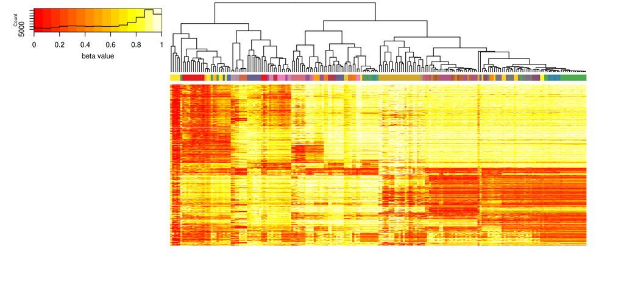

```r
 heatmap.2(filtered_score_matrix,labRow = NA, labCol = NA,
          trace = "none", ColSideColors = color_vector,
          hclust=function(x) hclust(x,method="complete"),
          distfun=function(x) as.dist(1-cor(t(x), method = "pearson")),
          Rowv = TRUE, dendrogram = "column",
          key.xlab = "beta value", denscol = "black", keysize = 1.5,
          key.title = NA)
```

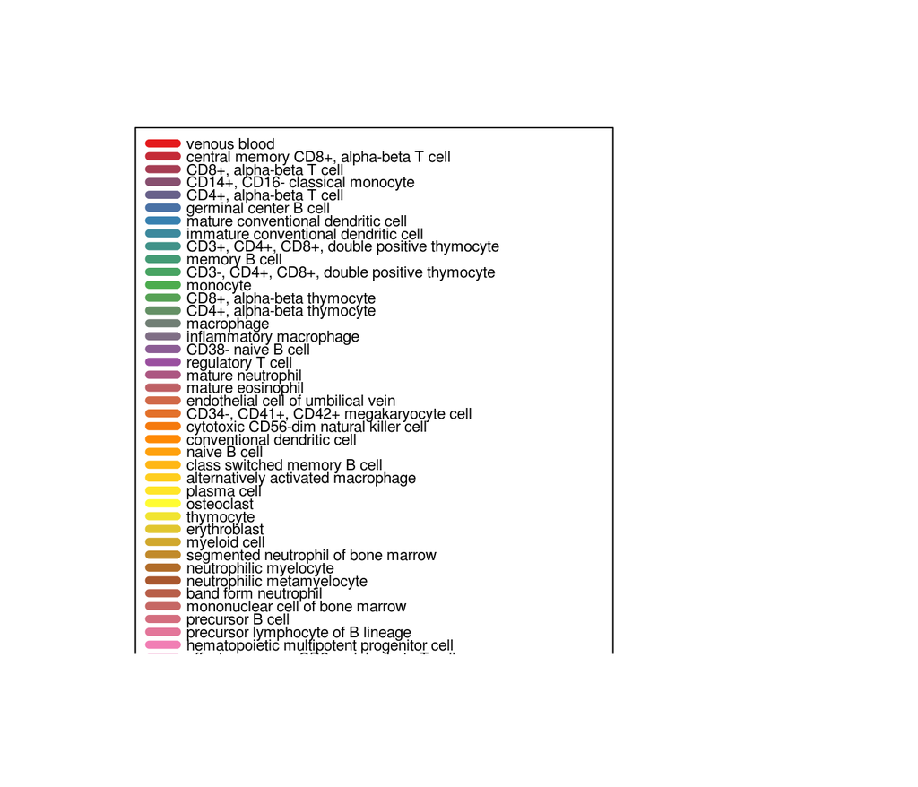

```r
  plot.new()

  legend(x = 0, y = 1,
       legend = color_map$biosource,
       col = as.character(color_map$color),
       text.width = 0.6,
       lty= 1,
       lwd = 6,
       cex = 0.7,
       y.intersp = 0.7,
       x.intersp = 0.7,
       inset=c(-0.21,-0.11))
```

# Further reading material

To obtain a general overview of DeepBlue, we recommend starting with the [DeepBlue publication](http://nar.oxfordjournals.org/lookup/doi/10.1093/nar/gkw211) and a list of all DeepBlue commands is available in its [API page](http://deepblue.mpi-inf.mpg.de/api.php).

You can have a look at the other use cases included in the R package and list them with

```r
demo(package = "DeepBlueR")
```

Individual use cases can be triggered with

```r
demo("use_case1", package = "DeepBlueR")
```

Note that the example presented here corresponds to use case 4 in the R package.

# Final remarks

Finally, we encourage you to try to reproduce [Python examples](http://deepblue.mpi-inf.mpg.de/examples.php) in R and to read the [DeepBlue manual](https://www.gitbook.com/book/felipealbrecht/deepblue-epigenomic-data-server-manual/details).

Finally, we want to highlight the possibility to browse and access existing data in DeepBlue conveniently in the [web interface](http://deepblue.mpi-inf.mpg.de). The web interface also allows you to select experiments in a grid like view.

Should you encounter any problems with DeepBlueR, we kindly ask you to create an issue in the BioConductor [DeepBlueR support page](https://support.bioconductor.org/t/deepbluer/).

The R code in the DeepBlueR package is under the GPLv3 license and we welcome contributions of other developers. Finally, we would like to thank the Bioconductor team for its support in making DeepBlueR available to a wide audience of users.